```python
from google.cloud import storage,bigquery
import json
import pandas as pd
import datetime
import numpy as np
import gcsfs
from pandas.io import gbq
import matplotlib.pyplot as plt
from matplotlib import cm
import seaborn as sns
import warnings
warnings.filterwarnings("ignore")
from matplotlib_venn import venn2, venn2_circles, venn2_unweighted
from folium import Choropleth, Circle, Marker, Map
from folium.plugins import HeatMap, MarkerCluster
import math
```

# Data transformation functions

```python
def fix_dict(dict_,date):
    dict_['date'] = date

    if dict_['longitude']=='null':
        dict_['longitude'] = None

    if dict_['latitude']=='null':
        dict_['latitude'] = None

    if dict_['location']=='null':
        dict_['location'] = None

    dict_['timestamp'] = dict_['timestamp'][:-3]

    dict_.pop('unique_key', None)
    dict_ = {k.capitalize():v for k,v in dict_.items()}
    return dict_

def fix_address(address):
    if 'BLOCK' in address:
        char = address.index('BLOCK')
        new_address = address[char:]
    else:
        new_address = address
    return new_address
```

# Creating a connection

Initializing google cloud storage client and creating a connection to the desired bucket.

```python
storage_client = storage.Client()
bucket = storage_client.get_bucket('arquivei-austin-incidents')
gcs_file_system = gcsfs.GCSFileSystem(project="bi-psel")
```

# Data

Taking a first look at a random data point to understand our data structure.

```python
blob_example = bucket.blob(r'2015-02-20/incidents.ndjson') # random date
data_json_example = json.loads(blob_example.download_as_string(client=None))
```

```python
data_json_example
```

```
{'unique_key': 2016530815,
 'descript': 'THEFT',
 'time': '12:00:00',
 'address': '700 BLOCK RIO GRANDE ST',
 'longitude': 'null',
 'latitude': 'null',
 'location': 'null',
 'timestamp': '2015-02-20 18:00:00+00'}
```

# Creating the GBQ Table

```python
from google.cloud import bigquery

PROJECT_ID = "bi-psel"
DATASET_ID = "samyr_neto"
TABLE_ID = "austin_data"

client = bigquery.Client()

# 1) create table
schema = [
            bigquery.SchemaField("Descript", "STRING", mode="REQUIRED"),
            bigquery.SchemaField("Date", "DATE", mode="REQUIRED"),
            bigquery.SchemaField("Time", "TIME", mode="REQUIRED"),
            bigquery.SchemaField("Address", "STRING", mode="REQUIRED"),
            bigquery.SchemaField("Longitude", "FLOAT", mode="NULLABLE"),
            bigquery.SchemaField("Latitude", "FLOAT", mode="NULLABLE"),
            bigquery.SchemaField("Location", "STRING", mode="NULLABLE"),
            bigquery.SchemaField("Timestamp", "TIMESTAMP", mode="REQUIRED")
         ]

table = bigquery.Table(f"{PROJECT_ID}.{DATASET_ID}.{TABLE_ID}", schema=schema)
table = client.create_table(table)
```

# Function creation

Now we will define the function responsible for taking a date string as an input, retrieving the information related to that particular date, and uploading this information into our Google Big Query table.

```python
def load_data(date_string):
    global schema,table,client,gcs_file_system
    rows_to_insert = []
    try:
        datetime.datetime.strptime(date_string, '%Y-%m-%d')
    except ValueError:
        raise ValueError("Incorrect date format,input should be YYYY-MM-DD")

    gcs_json_path = "gs://arquivei-austin-incidents/{}/incidents.ndjson".format(date_string)

    with gcs_file_system.open(gcs_json_path) as f:
        json_data = [json.loads(line) for line in f]

    for single_json in json_data:
        single_json = fix_dict(single_json,date_string)
        rows_to_insert.append(single_json)

    client.insert_rows(rows = rows_to_insert,table = table,selected_fields = schema)
    return
```

# Uploading the data to GBQ

And saving it in a dataframe.

```python
blobs = storage_client.list_blobs(bucket)
dates = [blob.name[0:10] for blob in blobs] #retrieving the 'date' string to feed the load_data function
```

```python
for date in dates:
    load_data(date)
```

```python
full_table_query = "SELECT * FROM `bi-psel.samyr_neto.austin_data`"
df = gbq.read_gbq(full_table_query,project_id = 'bi-psel') # saving the full table in a dataframe
```

```python
df
```

|  | Descript | Date | Time | Address | Longitude | Latitude | Location | Timestamp |
| --- | --- | --- | --- | --- | --- | --- | --- | --- |
| 0 | IDENTITY THEFT | 2015-10-15 | 14:11:00 | 2500 BLOCK W PARMER LN | NaN | NaN | None | 2015-10-15 20:11:00+00:00 |
| 1 | IDENTITY THEFT | 2015-12-14 | 00:00:00 | 9800 BLOCK N FM 620 RD | NaN | NaN | None | 2015-12-14 06:00:00+00:00 |
| 2 | AUTO THEFT | 2015-12-23 | 09:00:00 | 7700 BLOCK S IH 35 SVRD NB | NaN | NaN | None | 2015-12-23 15:00:00+00:00 |
| 3 | CRIMINAL MISCHIEF | 2015-12-17 | 00:00:00 | 8500 BLOCK TUSCANY WAY | NaN | NaN | None | 2015-12-17 06:00:00+00:00 |
| 4 | CRUELTY TO ANIMALS | 2015-12-01 | 10:00:00 | 1600 BLOCK ASTOR PL | NaN | NaN | None | 2015-12-01 16:00:00+00:00 |
| ... | ... | ... | ... | ... | ... | ... | ... | ... |
| 45117 | CRIMINAL TRESPASS NOTICE | 2016-04-04 | 11:07:00 | 7800 BLOCK BURNET RD | NaN | NaN | None | 2016-04-04 17:07:00+00:00 |
| 45118 | ASSAULT WITH INJURY | 2016-04-04 | 19:40:00 | GOODWIN AVE / PAUL TERESA SALDANA ST | -97.702525 | 30.270269 | (30.27026931,-97.70252519) | 2016-04-05 01:40:00+00:00 |
| 45119 | FAMILY DISTURBANCE | 2016-04-04 | 23:43:00 | 6600 BLOCK S MOPAC EXPY SVRD SB | NaN | NaN | None | 2016-04-05 05:43:00+00:00 |
| 45120 | ASSAULT INFO (FAMILY VIOLENCE | 2016-04-04 | 13:25:00 | 300 BLOCK W 11TH ST | NaN | NaN | None | 2016-04-04 19:25:00+00:00 |
| 45121 | OUT OF CITY OFFENSE | 2016-04-04 | 15:21:00 | 9800 BLOCK ANDERSON MILL RD | NaN | NaN | None | 2016-04-04 21:21:00+00:00 |

45122 rows × 8 columns

# Demonstrational SQL Queries

All of the next filters could be easily done using the Pandas library. The following queries are for demonstrational purposes only, showing that you can apply SQL queries to retrieve information from GBQ and saving them in a dataframe. We will only use the second query.

```python
# counting descripts
descript_value_counts_query = """SELECT Descript,COUNT(Descript) AS value_counts
                                 FROM `bi-psel.samyr_neto.austin_data`
                                 GROUP BY (Descript)
                                 ORDER BY  value_counts DESC"""

# returning data containing geographical information
geo_data_query = """SELECT *
                    FROM `bi-psel.samyr_neto.austin_data`
                    WHERE Longitude is not null"""

# counting crimes per month. (With BigQuery, you cannot use the derived column within the same select,
# hence the subquery)
crimes_per_month_query ="""SELECT year_month,COUNT(year_month) AS value_counts
                            FROM (
                                SELECT LEFT(CAST(Timestamp as string),7) AS year_month
                                FROM `bi-psel.samyr_neto.austin_data`
                                )
                            GROUP BY year_month
                            ORDER BY value_counts DESC"""
```

# Checking data integrity

```python
# checking for duplicated rows
df.duplicated().value_counts()
```

```
False    45033
True        89
dtype: int64
```

```python
df[df.duplicated()]
```

|  | Descript | Date | Time | Address | Longitude | Latitude | Location | Timestamp |
| --- | --- | --- | --- | --- | --- | --- | --- | --- |
| 817 | THEFT OF SERVICE | 2015-11-07 | 12:00:00 | 2400 BLOCK S CONGRESS AVE | NaN | NaN | None | 2015-11-07 18:00:00+00:00 |
| 1084 | THEFT | 2015-12-24 | 12:00:00 | 2900 BLOCK FRUTH ST | NaN | NaN | None | 2015-12-24 18:00:00+00:00 |
| 1598 | BURGLARY OF VEHICLE | 2016-04-05 | 20:00:00 | 4100 BLOCK GOVERNORS ROW | NaN | NaN | None | 2016-04-06 02:00:00+00:00 |
| 4933 | BURGLARY OF VEHICLE | 2016-07-31 | 17:30:00 | 3200 BLOCK ESPERANZA XING | NaN | NaN | None | 2016-07-31 23:30:00+00:00 |
| 5276 | THEFT | 2016-08-01 | 22:30:00 | 3200 BLOCK E MARTIN LUTHER KING JR BLVD | NaN | NaN | None | 2016-08-02 04:30:00+00:00 |
| ... | ... | ... | ... | ... | ... | ... | ... | ... |
| 43767 | BURGLARY OF VEHICLE | 2016-04-01 | 04:30:00 | 4400 BLOCK S MOPAC EXPY SVRD SB | NaN | NaN | None | 2016-04-01 10:30:00+00:00 |
| 43795 | THEFT OF SERVICE | 2016-04-01 | 00:00:00 | 12900 BLOCK N IH 35 SVRD NB | NaN | NaN | None | 2016-04-01 06:00:00+00:00 |
| 43807 | BURGLARY OF VEHICLE | 2016-04-01 | 18:30:00 | 4300 BLOCK NIXON LN | NaN | NaN | None | 2016-04-02 00:30:00+00:00 |
| 44085 | BURGLARY OF VEHICLE | 2016-04-02 | 08:23:00 | 700 BLOCK E STASSNEY LN | NaN | NaN | None | 2016-04-02 14:23:00+00:00 |
| 44231 | BURGLARY OF VEHICLE | 2016-04-02 | 08:23:00 | 700 BLOCK E STASSNEY LN | NaN | NaN | None | 2016-04-02 14:23:00+00:00 |

89 rows × 8 columns

```python
# it wouldn't change much, but let's delete the duplicated rows for the sake of good practice
df = df.drop_duplicates()
```

We are also aware that we've got some NaN values in our data. However, as we are not planning on using any machine learning algorithms, I don't see them being problematic. Let's not bother to replace them with something else. Moving on:

# Understanding the data at hand

Before anything, lets understand what information we have available

```python
print(f'Our dataset contains {len(df["Descript"].unique())} distinct crime types')
```

```
Our dataset contains 366 distinct crime types
```

```python
df['Date'].dt.month.value_counts()
```

```
3     13206
2     11910
1      7361
8      5989
4      3469
7      2072
12      544
11      188
10      128
9        93
6        37
5        36
Name: Date, dtype: int64
```

Apparently we have data points for all of the 12 months. However, I find it hard to believe that March for some reason is 367x more dangerous than May. We might have some issues with our data.

```python
df['Date'].dt.year.value_counts()
```

```
2016    43844
2015     1189
Name: Date, dtype: int64
```

Out of curiosity, we will treat each year separately and investigate its properties.

```python
df_2015 = df[df['Date'].dt.year==2015]
df_2016 = df[df['Date'].dt.year==2016]

# creating month columns to make our lifes easier

df_2015['Month'] = df_2015['Date'].dt.month
df_2016['Month'] = df_2016['Date'].dt.month
```

# The bigger picture

Lets analyze how crime behaves in austin from a macro perspective

```python
# for this visual we will not filter by year, since we already have a small amount of geographical data points
m = Map(location=[30.266666, -97.733330], zoom_start=13, ) # setting Austin location
geo_data = gbq.read_gbq(geo_data_query,project_id = 'bi-psel')
HeatMap(data=geo_data[['Latitude','Longitude']], radius=12).add_to(m) #adding occurences locations to map
m
```

Make this Notebook Trusted to load map: File -> Trust Notebook

[interactive chart not shown]

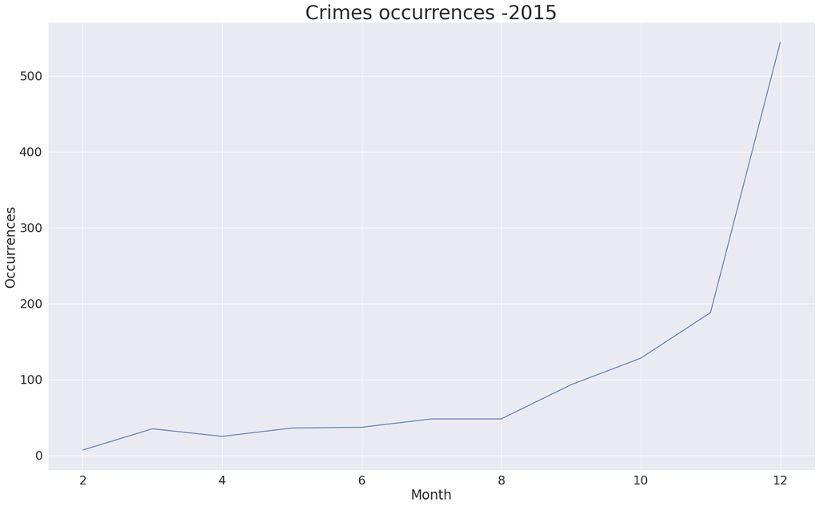

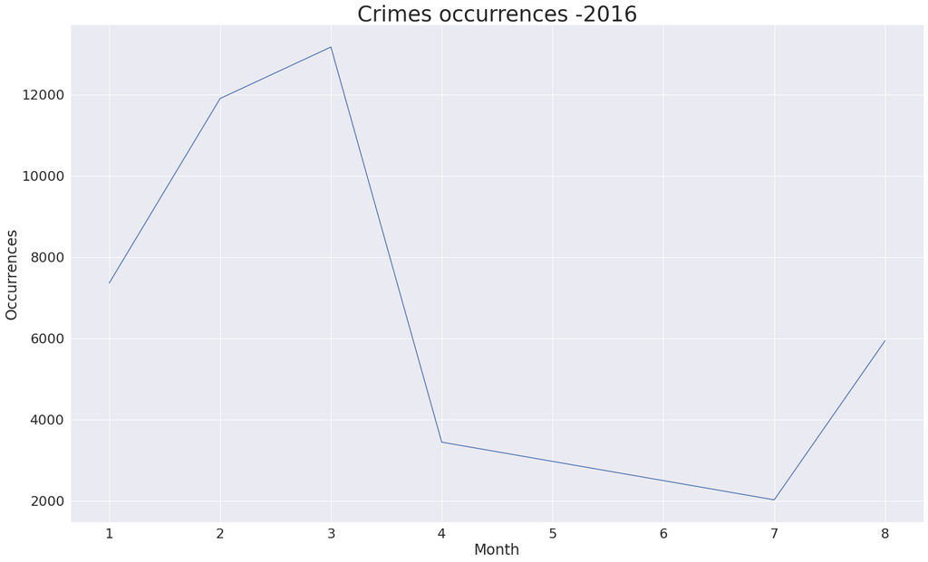

```python
for data,year in zip([df_2015,df_2016],['2015','2016']):
    sns.set(style='darkgrid',font_scale = 2)
    plt.figure(figsize=(25, 15))
    plt.title(f'Crimes occurrences -{year}',fontdict={'fontsize': 35})
    sns.lineplot(x=data['Month'].value_counts().index,y = data['Month'].value_counts().values)
    plt.xlabel("Month")
    plt.ylabel("Occurrences")
```

It looks like crime rate skyrockets towards the end of the 2015. There is a clear trend starting from month 8, reaching its peak at month 12. We have no data on the first month of 2015.

Analyzing the plot behavior of 2016, we can conclude that the trend continues up until month 3. For some reason, crime occurrences are plummeted at month 4. We can draw many hypothesis on why this happens, however, blindly guessing is out of the scope. Crime occurrences stay relatively low, tripling from month 7 to 8.

# Getting to know Austin's crimes

As we saw previously, our dataset contains 366 distinct types of crime. Lets see the distributions for each year: Visualizing all of these might not be very practical. Let's decide our study range.

```python
print(f'Our 2015 dataset contains {len(df_2015["Descript"].unique())} distinct crime types')
print(f'Our 2016 dataset contains {len(df_2016["Descript"].unique())} distinct crime types')
```

```
Our 2015 dataset contains 98 distinct crime types
Our 2016 dataset contains 364 distinct crime types
```

Visualizing all of these might not be very practical. Let's decide our study range.

```python
print(f'The 30 most common crimes of 2015 represents {df_2015["Descript"].value_counts().head(30).sum()/df_2015.shape[0]} of the crime occurrences')
print(f'The 30 most common crimes of 2016 represents {df_2016["Descript"].value_counts().head(30).sum()/df_2016.shape[0]} of the crime occurrences')
```

```
The 30 most common crimes of 2015 represents 0.8805719091673675 of the crime occurrences
The 30 most common crimes of 2016 represents 0.7027187300428793 of the crime occurrences
```

With these ratios, I believe we can get a good picture on the scenarios for both years. Lets select these represenative crimes for each dataframe and work with them.

```python
# selecting the desired crimes
crimes_2015 = df_2015['Descript'].value_counts().head(30)
crimes_2016 = df_2016['Descript'].value_counts().head(30)
```

```python
crimes_2016
```

```
CRASH/LEAVING THE SCENE           3688
THEFT                             2809
FAMILY DISTURBANCE                2709
BURGLARY OF VEHICLE               2370
CRIMINAL TRESPASS NOTICE          1855
CRIMINAL MISCHIEF                 1670
LOST PROP                         1102
DWI                                993
THEFT BY SHOPLIFTING               986
DISTURBANCE - OTHER                963
ASSAULT W/INJURY-FAM/DATE VIOL     876
BURGLARY OF RESIDENCE              785
HARASSMENT                         771
POSS MARIJUANA                     699
PUBLIC INTOXICATION                691
AUTO THEFT                         675
REQUEST TO APPREHEND               674
WARRANT ARREST NON TRAFFIC         649
FOUND PROPERTY                     614
ASSAULT WITH INJURY                613
POSS CONTROLLED SUB/NARCOTIC       587
CUSTODY ARREST TRAFFIC WARR        536
DRIVING WHILE LICENSE INVALID      493
EMERGENCY PROTECTIVE ORDER         484
ASSAULT BY CONTACT                 479
BURGLARY NON RESIDENCE             475
FRAUD - OTHER                      464
THEFT OF BICYCLE                   398
CRIMINAL TRESPASS                  376
IDENTITY THEFT                     326
Name: Descript, dtype: int64
```

Adjusting our dataframes with only those crimes:

```python
# filtering the complete dateframe based on the selected crimes
selected_2015 = df_2015[df_2015['Descript'].isin(crimes_2015.index)]
selected_2016 = df_2016[df_2016['Descript'].isin(crimes_2016.index)]
```

Analyzing quantity of crimes by type

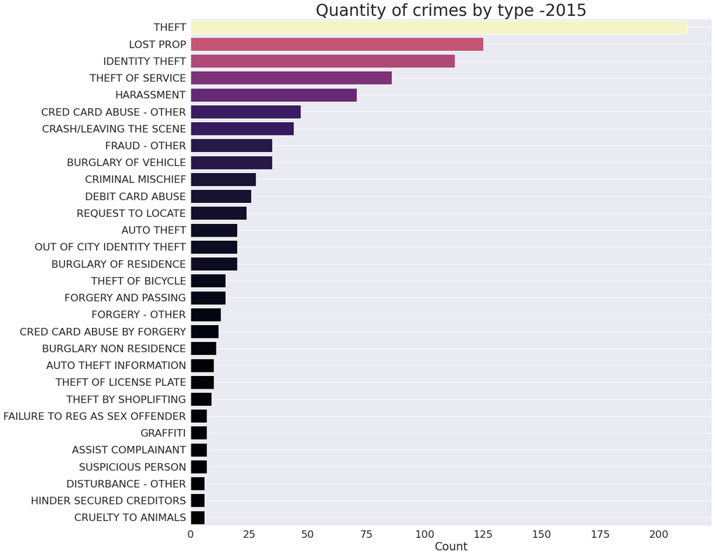

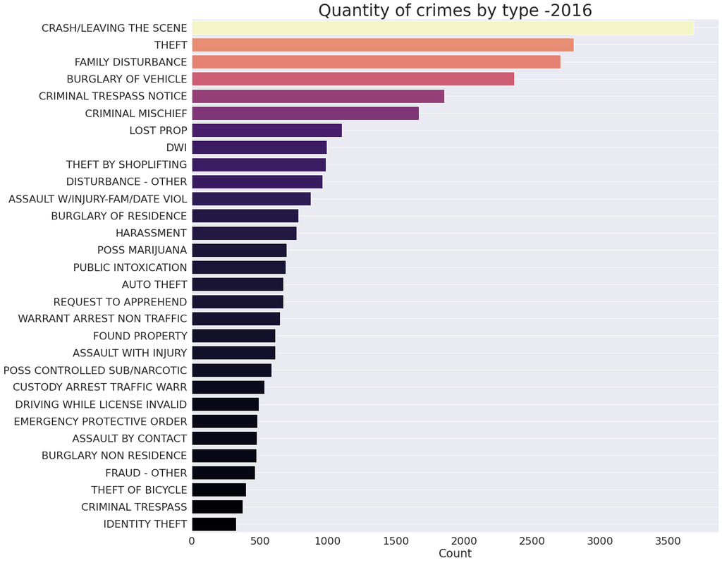

```python
for data,year in zip([crimes_2015,crimes_2016],['2015','2016']):
    plt.figure(figsize=(20, 20))

    ax = sns.barplot(data.values,
                     data.index,
                     palette=cm.ScalarMappable(cmap='magma').to_rgba(data))

    plt.rcParams.update({'font.size': 23})
    plt.title(f'Quantity of crimes by type -{year}', fontdict={'fontsize': 35})
    plt.xlabel('Count')
    plt.grid()
```

Surprisingly, we can see that the most occured crime in 2016 is the 7th in 2015. At first glance we can see that most occurred crimes in 2015 and 2016 aren't the same. Lets take a deeper look:

```python
common_crimes = list(set(crimes_2015.index).intersection(crimes_2016.index)) # common top 30 crimes in 2015 and 2016
common_crimes
```

```
['THEFT BY SHOPLIFTING',
 'AUTO THEFT',
 'IDENTITY THEFT',
 'HARASSMENT',
 'THEFT',
 'THEFT OF BICYCLE',
 'BURGLARY OF VEHICLE',
 'LOST PROP',
 'FRAUD - OTHER',
 'DISTURBANCE - OTHER',
 'CRIMINAL MISCHIEF',
 'CRASH/LEAVING THE SCENE',
 'BURGLARY OF RESIDENCE',
 'BURGLARY NON RESIDENCE']
```

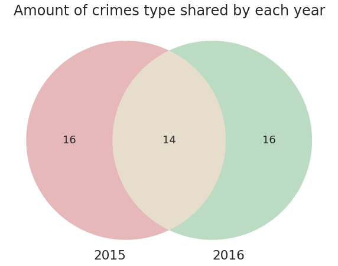

```python
# very simple representation, but making sure to keep the data discoveries visual
plt.figure(figsize=(10, 10))
plt.rcParams.update({'font.size': 18})
venn2(subsets = (30-len(common_crimes),
                 30-len(common_crimes),
                 len(common_crimes)),
                  set_labels = ('2015', '2016'))
plt.title('Amount of crimes type shared by each year')
```

# Top 5 crimes evolution for each year

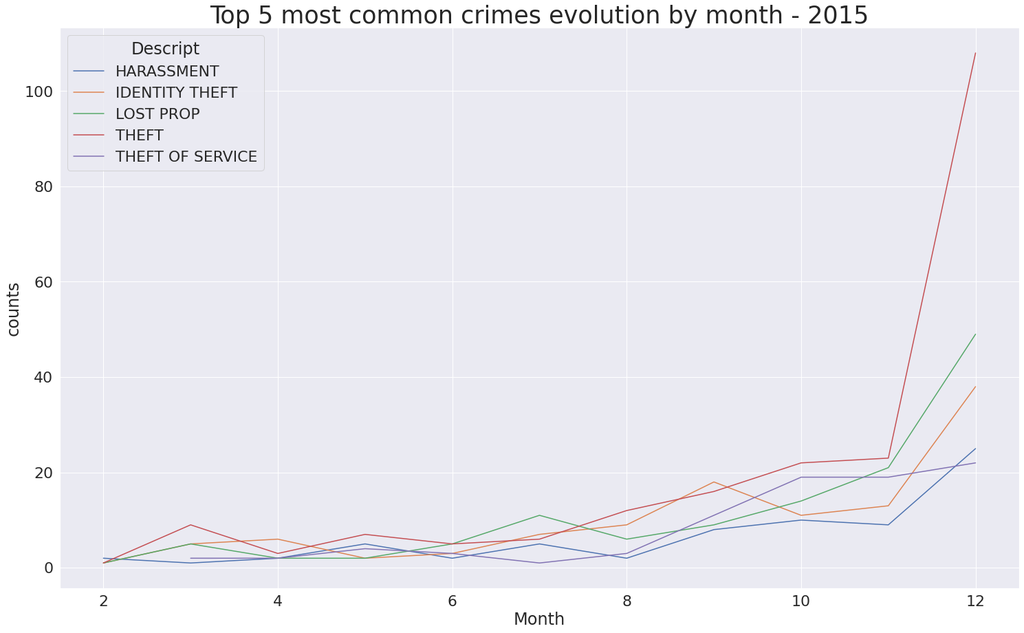

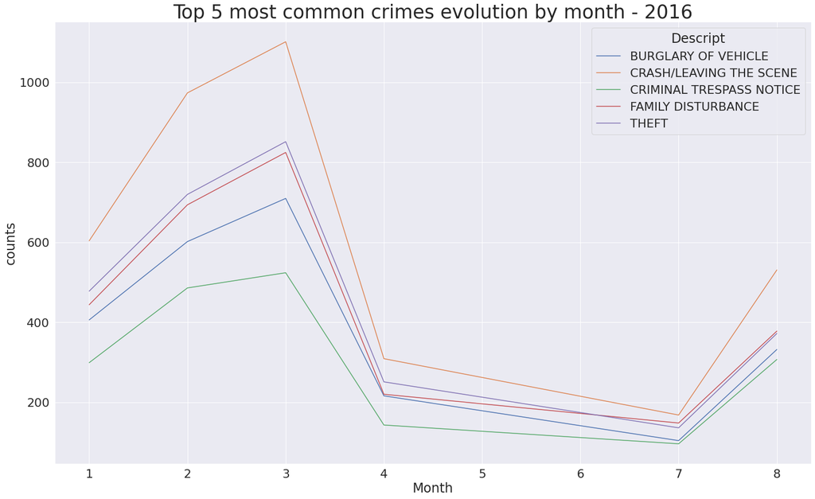

```python
for data,year,crimes in zip([df_2015,df_2016],['2015','2016'],[crimes_2015,crimes_2016]):
    top_5 = data[data['Descript'].isin(crimes.head(5).index)]
    top_5 = top_5.groupby(['Descript', 'Month']).size().reset_index() # counts of descript and month pairs
    top_5.rename(columns={0:'counts'},inplace=True)
    plt.figure(figsize=(25, 15))
    plt.title(f'Top 5 most common crimes evolution by month - {year}',fontdict={'fontsize': 35})
    sns.lineplot(data=top_5, x="Month",y='counts',hue="Descript")
```

# Most dangerous hours

```python
hours_2015 = df_2015['Timestamp'].dt.hour.value_counts()
hours_2016 = df_2016['Timestamp'].dt.hour.value_counts()
```

```python
hours_2016
```

```
18    2817
23    2494
0     2433
6     2379
4     2368
1     2275
5     2243
3     2241
2     2171
21    2158
22    2132
20    2039
19    2011
16    1939
17    1896
7     1648
8     1568
15    1560
14    1342
13    1087
9     1062
10     711
12     688
11     582
Name: Timestamp, dtype: int64
```

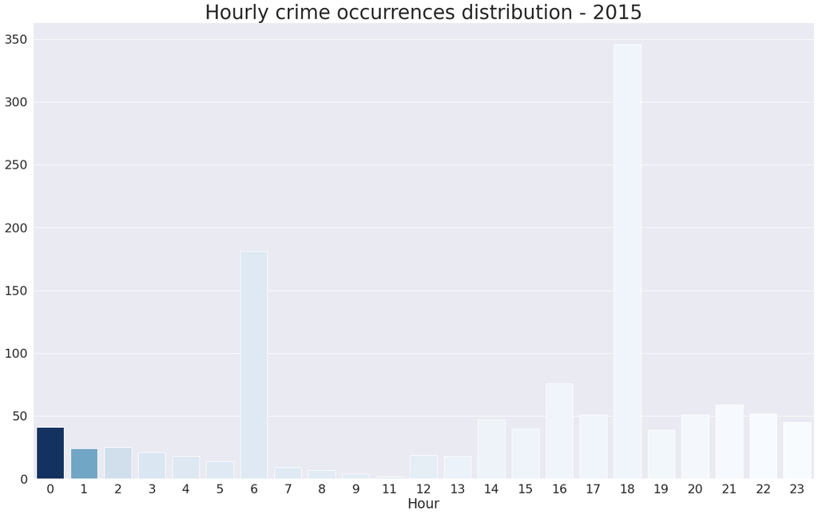

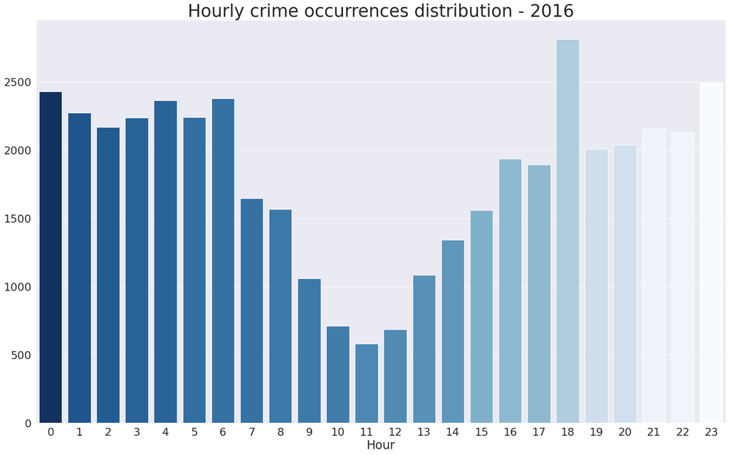

```python
for data,year in zip([hours_2015,hours_2016],['2015','2016']):
    plt.figure(figsize=(25, 15))
    sns.barplot(x=data.index,
                y= data.values,
                palette=cm.ScalarMappable(cmap='Blues').to_rgba(data.values))
    plt.title(f'Hourly crime occurrences distribution - {year}',fontdict={'fontsize': 35})
    plt.xlabel('Hour')
```

In 2015, crimes occurred mostly at 6 and 18. In 2016, we can see an inverted bell curve, with crime occurrences well distributed throught the day, with a notable decrease towards the middle of the day.

# Most dangerous areas

When we first printed our dataframe at the beggining of the code, we could see at first glance that most of the showing addresses contained the word 'BLOCK' in it. Lets see if the addresses registered are indeed blocks:

```python
print(f'{df_2015[df_2015["Address"].str.contains("BLOCK")].shape[0]/df_2015.shape[0]} of 2015 data has "BLOCK" in its address')
print(f'{df_2016[df_2016["Address"].str.contains("BLOCK")].shape[0]/df_2016.shape[0]} of 2016 data has "BLOCK" in its address')
```

```
0.9764507989907485 of 2015 data has "BLOCK" in its address
0.9190767265760423 of 2016 data has "BLOCK" in its address
```

Yes. The vast majority of our data points occurred in some block. Now we need to remove the address number to group the same blocks.

```python
df_2015['Block'] = df_2015['Address'].apply(fix_address) # creating a new column "Block"
df_2016['Block'] = df_2016['Address'].apply(fix_address)

top_10_blocks_2015 = df_2015['Block'].value_counts().head(10) # saving the most 10 most dangerous blocks of 2015
top_10_blocks_2016 = df_2016['Block'].value_counts().head(10)
```

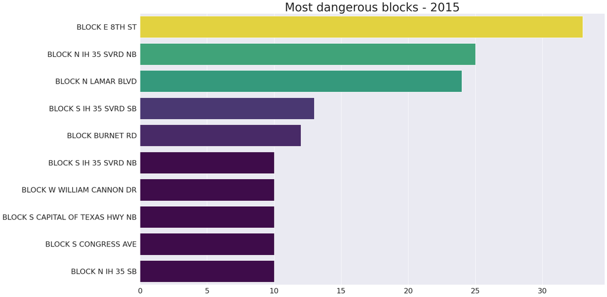

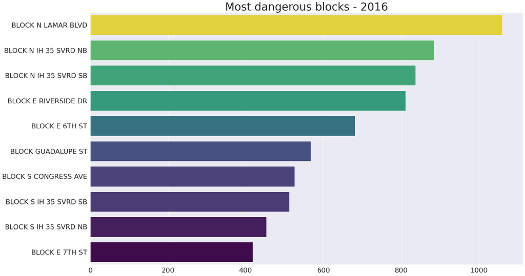

```python
for data,year in zip([top_10_blocks_2015,top_10_blocks_2016],['2015','2016']):
    plt.figure(figsize=(25, 15))
    sns.barplot(x=data.values,
                y= data.index,
                palette=cm.ScalarMappable(cmap='viridis').to_rgba(data.values))
    plt.title(f'Most dangerous blocks - {year}',fontdict={'fontsize': 35})
```

It might be interesting to know which crimes are most common for each of these blocks.

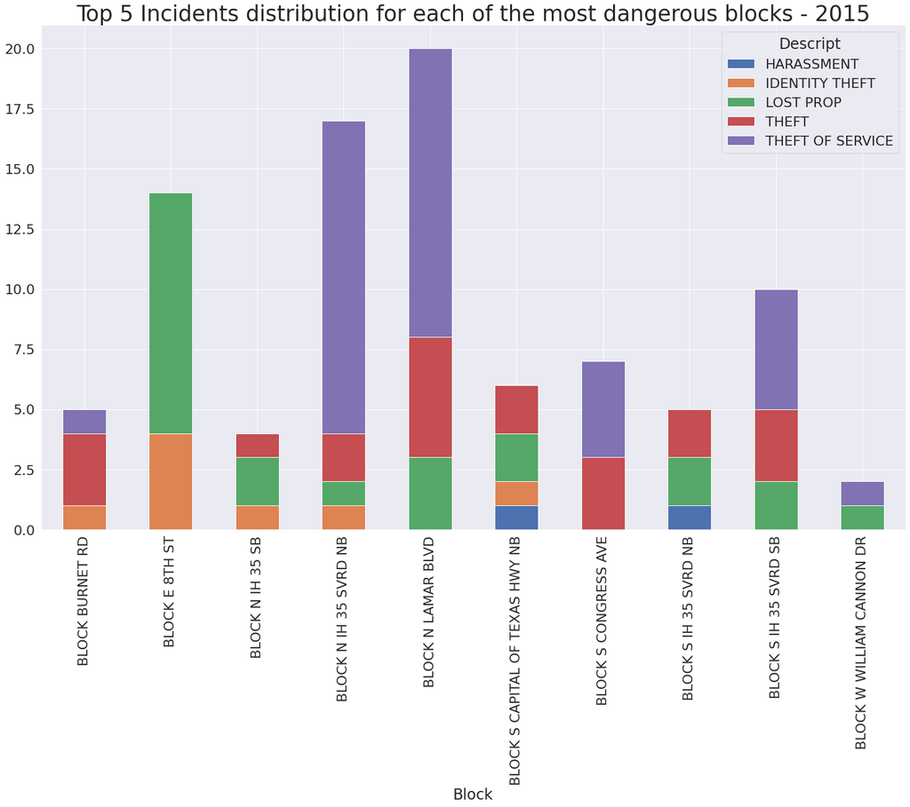

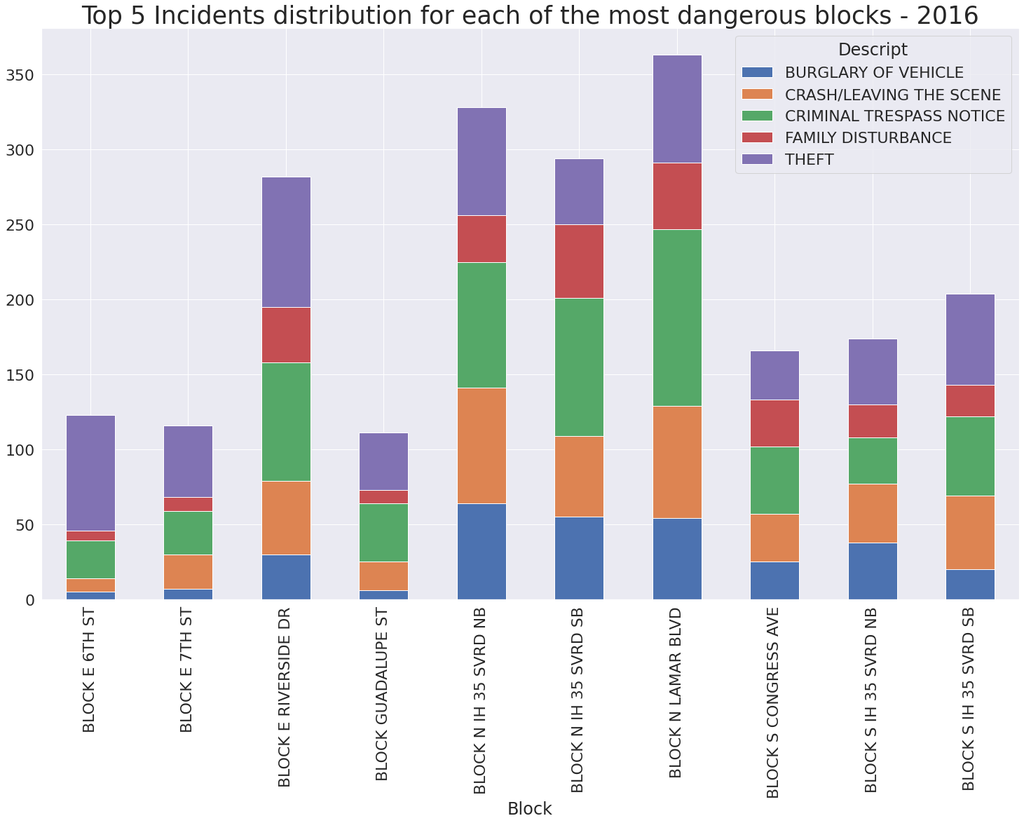

```python
for data,blocks,year,crimes in zip([df_2015,df_2016],[top_10_blocks_2015,top_10_blocks_2016],['2015','2016'],[crimes_2015,crimes_2016]):
    grouped_block_crimes = data[data['Block'].isin(blocks.index)] # selecting crimes that occured in blocks displayed above
    grouped_block_crimes = grouped_block_crimes[grouped_block_crimes['Descript'].isin(crimes.head(5).index)] # selecting only top 5 crimes in order to make the plot understandable
    tmp = grouped_block_crimes.groupby(['Descript','Block']).size().reset_index() # creating the desired groupby object
    tmp.reset_index(inplace=True) # converting it to a dataframe by reseting the index
    tmp.rename(columns={0:'counts'},inplace=True) # renaming the count columns
    tmp=tmp.pivot(index='Block',columns='Descript',values='counts') # pivoting the dataframe to achieve the desired structure to be plotted
    tmp.plot(kind='bar', stacked=True,figsize=(25,15))
    plt.title(f'Top 5 Incidents distribution for each of the most dangerous blocks - {year}',fontdict={'fontsize': 35})
```

## Conclusion

# Notes

Our data sample of 2016 is much larger than 2015. This should be considered when taking any data driven decisions. Theoretically, using the data from 2016 will be safer due to its larger sample size. One possible (and very viable) approach is to mix them together, since the 2016 data will heavily weight the results. They have been treated separately out of curiosity to investigate their differences.